# HW2_AK

```python
import numpy as np
import pandas as pd
import matplotlib.pyplot as plt
import seaborn as sns
import missingno as msno

from sklearn.linear_model import LinearRegression
from sklearn.preprocessing import PolynomialFeatures
```

```python
pd.set_option('display.max_columns', None)
df = pd.read_csv("match_data.csv")
```

```python
df.describe()
```

|  | fixture_id | minute | second | 1 | 2 | X | Accurate Crosses - away | Accurate Crosses - home | Assists - away | Assists - home | Attacks - away | Attacks - home | Ball Possession % - away | Ball Possession % - home | Ball Safe - away | Ball Safe - home | Challenges - away | Challenges - home | Corners - away | Corners - home | Counter Attacks - away | Counter Attacks - home | Dangerous Attacks - away | Dangerous Attacks - home | Dribble Attempts - away | Dribble Attempts - home | Fouls - away | Fouls - home | Free Kicks - away | … |
| --- | --- | --- | --- | --- | --- | --- | --- | --- | --- | --- | --- | --- | --- | --- | --- | --- | --- | --- | --- | --- | --- | --- | --- | --- | --- | --- | --- | --- | --- | --- |
| count | 6.394400e+04 | 63944.000000 | 63944.000000 | 63944.000000 | 63944.000000 | 63944.000000 | 60916.000000 | 60937.000000 | 36010.000000 | 36013.000000 | 63905.000000 | 63911.000000 | 63921.000000 | 63922.000000 | 40516.000000 | 40520.000000 | 59263.000000 | 59270.000000 | 63870.000000 | 63878.000000 | 22733.000000 | 22735.000000 | 63891.000000 | 63897.000000 | 56075.000000 | 56100.000000 | 62317.000000 | 62329.000000 | 5479.000000 | … |
| mean | 1.914800e+07 | 25.476526 | 27.695421 | 18.510137 | 29.482377 | 8.698023 | 2.010276 | 2.631209 | 0.812746 | 0.901397 | 45.907926 | 50.890692 | 49.020322 | 50.978990 | 32.811556 | 31.521422 | 4.606162 | 4.543040 | 2.139486 | 2.641457 | 1.367483 | 1.580603 | 19.913118 | 23.806705 | 8.238038 | 8.359251 | 6.268851 | 6.007589 | 6.737908 | … |
| std | 1.345825e+04 | 14.496434 | 18.289720 | 64.166275 | 82.639170 | 12.092077 | 1.950212 | 2.292960 | 0.794087 | 0.826550 | 29.741377 | 32.669453 | 14.408174 | 14.416121 | 20.747913 | 20.343393 | 3.256061 | 3.311643 | 2.149643 | 2.550065 | 1.525720 | 1.626110 | 15.585091 | 18.082858 | 5.261233 | 5.423759 | 4.356074 | 4.062397 | 4.882886 | … |
| min | 1.913445e+07 | 0.000000 | 0.000000 | 1.000000 | 1.000000 | 1.000000 | 0.000000 | 0.000000 | 0.000000 | 0.000000 | 0.000000 | 0.000000 | 0.000000 | 0.000000 | 0.000000 | 0.000000 | 0.000000 | 0.000000 | 0.000000 | 0.000000 | 0.000000 | 0.000000 | 0.000000 | 0.000000 | 1.000000 | 1.000000 | 0.000000 | 0.000000 | 0.000000 | … |
| 25% | 1.913530e+07 | 13.000000 | 10.000000 | 1.330000 | 1.950000 | 3.000000 | 0.000000 | 1.000000 | 0.000000 | 0.000000 | 21.000000 | 24.000000 | 39.000000 | 41.000000 | 16.000000 | 15.000000 | 2.000000 | 2.000000 | 0.000000 | 1.000000 | 0.000000 | 1.000000 | 8.000000 | 9.000000 | 4.000000 | 4.000000 | 3.000000 | 3.000000 | 3.000000 | … |
| 50% | 1.913974e+07 | 25.000000 | 27.000000 | 2.500000 | 4.000000 | 3.750000 | 2.000000 | 2.000000 | 1.000000 | 1.000000 | 43.000000 | 48.000000 | 49.000000 | 51.000000 | 32.000000 | 31.000000 | 4.000000 | 4.000000 | 2.000000 | 2.000000 | 1.000000 | 1.000000 | 17.000000 | 21.000000 | 7.000000 | 7.000000 | 6.000000 | 5.000000 | 6.000000 | … |
| 75% | 1.915513e+07 | 38.000000 | 44.000000 | 5.500000 | 13.000000 | 7.500000 | 3.000000 | 4.000000 | 1.000000 | 1.000000 | 67.000000 | 74.000000 | 59.000000 | 61.000000 | 48.000000 | 45.000000 | 7.000000 | 6.000000 | 3.000000 | 4.000000 | 2.000000 | 2.000000 | 29.000000 | 34.000000 | 12.000000 | 12.000000 | 9.000000 | 9.000000 | 10.000000 | … |
| max | 1.917212e+07 | 80.000000 | 59.000000 | 501.000000 | 501.000000 | 51.000000 | 12.000000 | 14.000000 | 5.000000 | 6.000000 | 180.000000 | 178.000000 | 100.000000 | 100.000000 | 266.000000 | 277.000000 | 21.000000 | 23.000000 | 18.000000 | 17.000000 | 10.000000 | 13.000000 | 163.000000 | 140.000000 | 33.000000 | 37.000000 | 28.000000 | 25.000000 | 27.000000 | … |

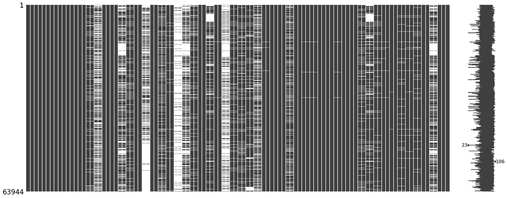

```python
# Display the null entries

msno.matrix(df)
```

## Task 1

```python
# Remove suspended or stopped matches

filtered_data = df[~(df['suspended'] | df['stopped'])].copy()
```

### 1. Calculating the probability for Home, Away and Draw

```python
filtered_data["Prob_1"] = 1 / filtered_data["1"]
filtered_data["Prob_2"] = 1 / filtered_data["2"]
filtered_data["Prob_X"] = 1 / filtered_data["X"]
```

### 2. Calculate the normalized probabilities

```python
total_prob = np.sum([filtered_data['Prob_1'], filtered_data['Prob_2'], filtered_data['Prob_X']], axis=0)
filtered_data[['Prob_normalize_1', 'Prob_normalize_2', 'Prob_normalize_X']] = filtered_data[['Prob_1', 'Prob_2', 'Prob_X']].div(total_prob, axis=0)
```

### 3. Draw probability graph construction

```python
first_half_data = filtered_data[filtered_data['halftime'] == '1st-half']
second_half_data = filtered_data[filtered_data['halftime'] == '2nd-half']
```

```python
# Function to evaluate the probability of a draw for each bin from the results of the matches
bins = np.arange(-1, 1.1, 0.1)

def calculate_empirical_prob(data, bins):
    data['P_diff'] = data['Prob_1'] - data['Prob_2']

    data['P_diff_bin'] = pd.cut(data['P_diff'], bins=bins, right=False)

    # Calculate the empirical probability of draw in each bin
    empirical_prob_by_bin = data.groupby('P_diff_bin').apply(
        lambda x: (x['result'] == 'X').sum() / len(x) if len(x) > 0 else 0
    ).fillna(0)

    return empirical_prob_by_bin
```

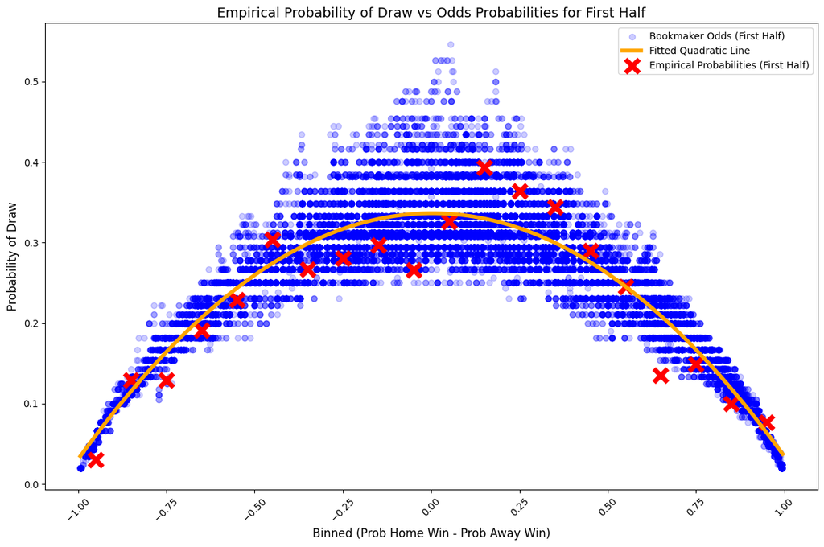

```python
# Firstly draw probabilities derived form the bookmaker odds is calculated and plotted
plt.figure(figsize=(12, 8))
plt.scatter(
    first_half_data['Prob_1'] - first_half_data['Prob_2'],  # P(home win) - P(away win) for each minute
    first_half_data['Prob_X'],
    color='blue', alpha=0.2, label="Bookmaker Odds (First Half)"
)


# A quadratic regression line is fitted to the plot in order to make an assessment between the empirical probabilities and odds probabilities.
X = (first_half_data['Prob_1'] - first_half_data['Prob_2']).values.reshape(-1, 1)  # Reshape for a single feature
y = first_half_data['Prob_X'].values

poly = PolynomialFeatures(degree=2)
X_poly = poly.fit_transform(X)  # This will generate [X, X^2]

model = LinearRegression()
model.fit(X_poly, y)

X_range = np.linspace(X.min(), X.max(), 1000).reshape(-1, 1)
X_range_poly = poly.transform(X_range)

y_range_pred = model.predict(X_range_poly)

# Plot the fitted quadratic curve
plt.plot(X_range, y_range_pred, color='orange', label="Fitted Quadratic Line", linewidth=4)


# After the odd probabilities are plotted and a quadratic line is fit, the emprical probabilities are also plotted for the selected bins
x_values_empirical = np.arange(-0.95, 1.0, 0.1)
empirical_prob_first_half = calculate_empirical_prob(first_half_data, bins)

plt.scatter(x_values_empirical, empirical_prob_first_half,s=200 ,alpha=1, color='red', marker="x", linewidths=5, label="Empirical Probabilities (First Half)")

plt.title("Empirical Probability of Draw vs Odds Probabilities for First Half", fontsize=14)
plt.xlabel("Binned (Prob Home Win - Prob Away Win)", fontsize=12)
plt.ylabel("Probability of Draw", fontsize=12)
plt.xticks(rotation=45)
plt.legend()
plt.tight_layout()
plt.show()
```

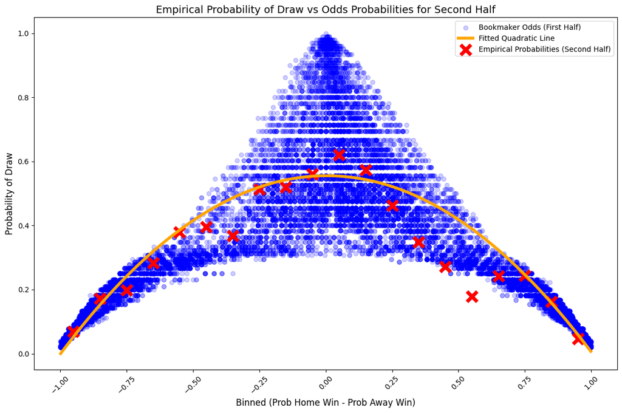

```python
# Firstly draw probabilities derived form the bookmaker odds is calculated and plotted

plt.figure(figsize=(12, 8))
plt.scatter(
    second_half_data['Prob_1'] - second_half_data['Prob_2'],
    second_half_data['Prob_X'],
    color='blue', alpha=0.2, label="Bookmaker Odds (First Half)"
)


# A quadratic regression line is fitted to the plot in order to make an assesment between the empirical probabilities and odds probabilities.
X = (second_half_data['Prob_1'] - second_half_data['Prob_2']).values.reshape(-1, 1)
y = second_half_data['Prob_X'].values

poly = PolynomialFeatures(degree=2)
X_poly = poly.fit_transform(X)  # This will generate [X, X^2]

model = LinearRegression()
model.fit(X_poly, y)

# Generate a range of values for X to plot the  curve
X_range = np.linspace(X.min(), X.max(), 1000).reshape(-1, 1)
X_range_poly = poly.transform(X_range)

y_range_pred = model.predict(X_range_poly)

# Plot the fitted quadratic curve
plt.plot(X_range, y_range_pred, color='orange', label="Fitted Quadratic Line", linewidth=4)

# Plot the empirical probabilities
x_values_empirical = np.arange(-0.95, 1.0, 0.1)
empirical_prob_second_half = calculate_empirical_prob(second_half_data, bins)
plt.scatter(x_values_empirical, empirical_prob_second_half,s=200 ,alpha=1, color='red', marker="x", linewidths=5, label="Empirical Probabilities (Second Half)")


plt.title("Empirical Probability of Draw vs Odds Probabilities for Second Half", fontsize=14)
plt.xlabel("Binned (Prob Home Win - Prob Away Win)", fontsize=12)
plt.ylabel("Probability of Draw", fontsize=12)
plt.xticks(rotation=45)
plt.legend()
plt.tight_layout()
plt.show()
```

### 4. Bias in Odds

- Commenting on the first half data, it can be deducted that the bookmaker tends to overestimate the probability of a draw, as the orange fitted line lies above most of the red "x" markers, which represent the empirical probabilities calculated from the results for each bin. Out of the 20 bins, only 5 have empirical probabilities that exceed the orange curve. This is reasonable, as bookmakers typically add a margin to ensure profitability, which results in slightly higher odds for each outcome. Therefore, it can be concluded that there is a bias between the empirical probabilities and the odds probabilities.
- Upon analyzing the second half data, it becomes even more apparent that there is a bias between the odds probabilities and the empirical probabilities, as only 2 or 3 empirical probabilities exceed the fitted line. This is again reasonable due to the bookmaker's margin. However, the main difference compared to the first half can likely be attributed to the increased noise in the data during the second half. Factors such as the score and remaining time have a significant impact, as some of the odds probabilities for a draw even approach 1 (likely due to data from the final moments of the match). Additionally, events like late goals, red cards, or injuries can severely influence the outcome of a match, which may explain the higher bookmaker probabilities observed in certain instances.

## Task 2

```python
initial_number_of_matches = len(filtered_data["fixture_id"].unique())
initial_number_of_matches

# Remove the matches if there is a late goal after the 90th minute

invalid_fixture_ids = filtered_data[
    (filtered_data["minute"] >= 45) &
    (filtered_data["halftime"] == "2nd-half") &
    (filtered_data["Score Change - away"] != 0)
]['fixture_id'].unique()

invalid_fixture_ids

late_goals_removed = filtered_data[~filtered_data['fixture_id'].isin(invalid_fixture_ids)]

number_of_matches_after_removing_late_goals = len(late_goals_removed["fixture_id"].unique())
print("Number of matches remained after removing the matches with late goals: ", number_of_matches_after_removing_late_goals)
print(f"Amount of matchs removed: {initial_number_of_matches - number_of_matches_after_removing_late_goals}")

# Remove the matches with early red cards within the first 25 minutes

invalid_fixture_ids = late_goals_removed[
    ((late_goals_removed["Redcards - away"] > 0) & (late_goals_removed["minute"] <= 25) & (late_goals_removed["halftime"] == "1st-half")) |
    ((late_goals_removed["Redcards - home"] > 0) & (late_goals_removed["minute"] <= 25) & (late_goals_removed["halftime"] == "1st-half"))
]['fixture_id'].unique()

early_red_cards_removed = late_goals_removed[~late_goals_removed['fixture_id'].isin(invalid_fixture_ids)]

number_of_matches_after_removing_early_red_cards = len(early_red_cards_removed["fixture_id"].unique())
print("Number of matches remained after removing the matches with early red cards: ", number_of_matches_after_removing_early_red_cards)
print(f"Amount of matchs removed: {number_of_matches_after_removing_late_goals - number_of_matches_after_removing_early_red_cards}")

# Remove the matches with an early substituiton. This is probably due to an extreme case.

invalid_fixture_ids = early_red_cards_removed[
    ((early_red_cards_removed["Substitutions - home"] >= 1) & (early_red_cards_removed["minute"] <= 25) & (early_red_cards_removed["halftime"] == "1st-half")) |
    ((early_red_cards_removed["Substitutions - away"] >= 1) & (early_red_cards_removed["minute"] <= 25) & (early_red_cards_removed["halftime"] == "1st-half"))
]['fixture_id'].unique()

early_sub_removed = early_red_cards_removed[~early_red_cards_removed['fixture_id'].isin(invalid_fixture_ids)]

number_of_matches_after_removing_early_sub = len(early_sub_removed["fixture_id"].unique())

print("Number of matches remained after removing the matches with early substitutions: ", number_of_matches_after_removing_early_sub)
print(f"Amount of matches removed: {number_of_matches_after_removing_early_red_cards - number_of_matches_after_removing_early_sub}")

total_removed_games = filtered_data["fixture_id"].nunique() - early_sub_removed["fixture_id"].nunique()
print("Total removed games: ", total_removed_games)
```

```
Number of matches remained after removing the matches with late goals:  618
Amount of matchs removed: 30
Number of matches remained after removing the matches with early red cards:  610
Amount of matchs removed: 8
Number of matches remained after removing the matches with early substitutions:  550
Amount of matches removed: 60
Total removed games:  98
```

### 3. Draw probability graph construction

```python
first_half_data2 = early_sub_removed[early_sub_removed['halftime'] == '1st-half']
second_half_data2 = early_sub_removed[early_sub_removed['halftime'] == '2nd-half']
```

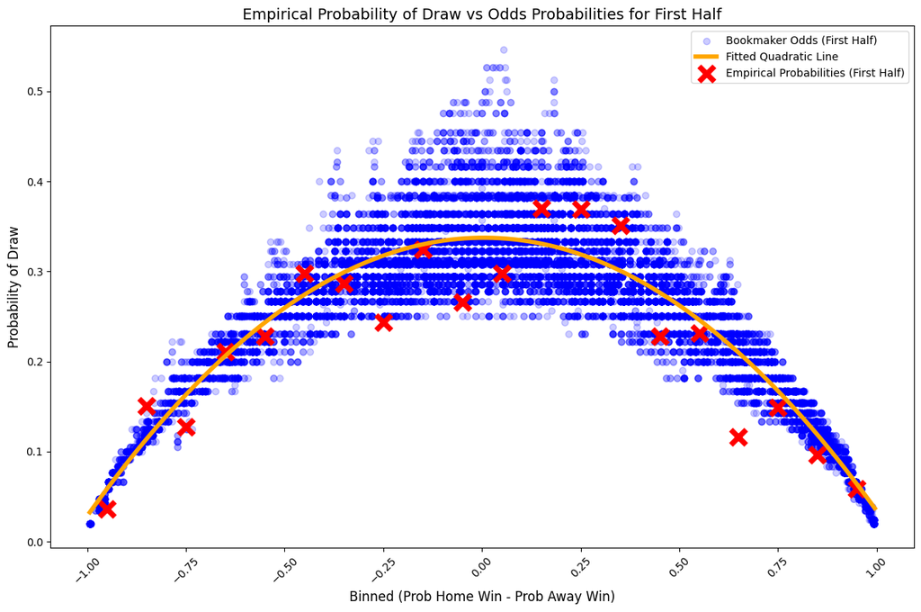

```python
# Firstly draw probabilities derived form the bookmaker odds is calculated and plotted
plt.figure(figsize=(12, 8))
plt.scatter(
    first_half_data2['Prob_1'] - first_half_data2['Prob_2'],  # P(home win) - P(away win) for each minute
    first_half_data2['Prob_X'],
    color='blue', alpha=0.2, label="Bookmaker Odds (First Half)"
)


# A quadratic regression line is fitted to the plot in order to make an assessment between the empirical probabilities and odds probabilities.
X = (first_half_data2['Prob_1'] - first_half_data2['Prob_2']).values.reshape(-1, 1)
y = first_half_data2['Prob_X'].values

poly = PolynomialFeatures(degree=2)
X_poly = poly.fit_transform(X)  # This will generate [X, X^2]

model = LinearRegression()
model.fit(X_poly, y)

# Generate a range of values for X to plot the curve
X_range = np.linspace(X.min(), X.max(), 1000).reshape(-1, 1)
X_range_poly = poly.transform(X_range)

y_range_pred = model.predict(X_range_poly)

# Plot the fitted quadratic curve
plt.plot(X_range, y_range_pred, color='orange', label="Fitted Quadratic Line", linewidth=4)


# Plot the empirical probabilities
x_values_empirical = np.arange(-0.95, 1.0, 0.1)
empirical_prob_first_half = calculate_empirical_prob(first_half_data2, bins)

plt.scatter(x_values_empirical, empirical_prob_first_half,s=200 ,alpha=1, color='red', marker="x", linewidths=5, label="Empirical Probabilities (First Half)")

plt.title("Empirical Probability of Draw vs Odds Probabilities for First Half", fontsize=14)
plt.xlabel("Binned (Prob Home Win - Prob Away Win)", fontsize=12)
plt.ylabel("Probability of Draw", fontsize=12)
plt.xticks(rotation=45)
plt.legend()
plt.tight_layout()
plt.show()
```

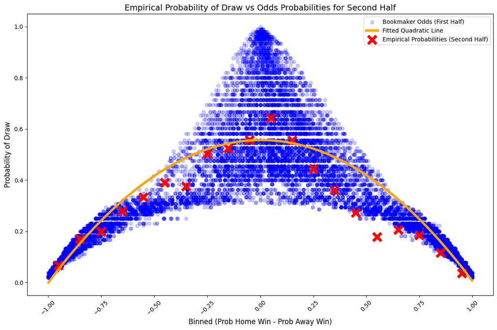

```python
# Firstly draw probabilities derived form the bookmaker odds is calculated and plotted

plt.figure(figsize=(12, 8))
plt.scatter(
    second_half_data2['Prob_1'] - second_half_data2['Prob_2'],
    second_half_data2['Prob_X'],
    color='blue', alpha=0.2, label="Bookmaker Odds (First Half)"
)


# A quadratic regression line is fitted to the plot in order to make an assesment between the empirical probabilities and odds probabilities.
X = (second_half_data2['Prob_1'] - second_half_data2['Prob_2']).values.reshape(-1, 1)
y = second_half_data2['Prob_X'].values

poly = PolynomialFeatures(degree=2)
X_poly = poly.fit_transform(X)  # This will generate [X, X^2]

model = LinearRegression()
model.fit(X_poly, y)

# Generate a range of values for X to plot the curve
X_range = np.linspace(X.min(), X.max(), 1000).reshape(-1, 1)
X_range_poly = poly.transform(X_range)

y_range_pred = model.predict(X_range_poly)

# Plot the fitted quadratic curve
plt.plot(X_range, y_range_pred, color='orange', label="Fitted Quadratic Line", linewidth=4)

# Plot the empirical probabilities
x_values_empirical = np.arange(-0.95, 1.0, 0.1)
empirical_prob_second_half = calculate_empirical_prob(second_half_data2, bins)
plt.scatter(x_values_empirical, empirical_prob_second_half,s=200 ,alpha=1, color='red', marker="x", linewidths=5, label="Empirical Probabilities (Second Half)")


plt.title("Empirical Probability of Draw vs Odds Probabilities for Second Half", fontsize=14)
plt.xlabel("Binned (Prob Home Win - Prob Away Win)", fontsize=12)
plt.ylabel("Probability of Draw", fontsize=12)
plt.xticks(rotation=45)
plt.legend()
plt.tight_layout()
plt.show()
```

## Task 3

```python
import optuna
from sklearn.tree import DecisionTreeClassifier
from sklearn.model_selection import cross_val_score
from sklearn.model_selection import train_test_split
from sklearn.metrics import confusion_matrix, ConfusionMatrixDisplay, accuracy_score, f1_score
```

```python
f = filtered_data.columns.to_list()  # Convert DataFrame columns to a list
columns_to_remove = [
    'fixture_id', 'halftime', 'current_time', 'half_start_datetime', 'match_start_datetime',
    'minute', 'second', 'latest_bookmaker_update', 'suspended', 'stopped', '1', '2', 'X',
    'name', 'ticking', "final_score","result","Prob_1", "Prob_2","Prob_X","Prob_normalize_1","Prob_normalize_2","Prob_normalize_X","P_diff","P_diff_bin"
]

f = [col for col in f if col not in columns_to_remove]

# Fill the NaN values with zero as they are null because there is no data available
feature_df = filtered_data[f].fillna(0)

feature_df["current_state_encoded"] = filtered_data['current_state'].replace({'1': 1, '2': 2, 'X': 0})

# Give the statistics of the data as the features of the decision tree
game_stats = feature_df[["Assists - away", "Assists - home", "Attacks - away", "Attacks - home",
                        'Ball Possession % - away', "Ball Possession % - home", "Challenges - away",
                        "Challenges - home", "Corners - away", "Corners - home", "Dangerous Attacks - away", "Dangerous Attacks - home",
                        "Fouls - away", "Fouls - home","Free Kicks - away", "Free Kicks - home", "Goal Attempts - away","Goal Attempts - home",
                        "Goals - away","Goals - home", "Injuries - away", "Injuries - home",
                        "Passes - away", "Passes - home", "Penalties - away", "Penalties - home",
                        "Redcards - away","Redcards - home", "Saves - away", "Saves - home",
                        "Shots Blocked - away", "Shots Blocked - home", "Shots Insidebox - away", "Shots Insidebox - home",
                        "Shots On Target - away", "Shots On Target - home", "Shots Total - away", "Shots Total - home",
                        "Substitutions - away", "Substitutions - home", "Successful Passes - away", "Successful Passes - home",
                        "Total Crosses - away", "Total Crosses - home"]]
```

```python
filtered_data['result_encoded'] = filtered_data['result'].replace({'1': 1, '2': 2, 'X': 0})

X = game_stats
y = filtered_data['result_encoded']

X_train, X_test, y_train, y_test = train_test_split(X, y, test_size=0.2, random_state=42)
```

```python
# Use optuna in order to determine on the hyperparameters that will be used in our decision tree

def objective(trial):

    max_depth = trial.suggest_int('max_depth', 5, 15)
    min_samples_split = trial.suggest_int('min_samples_split', 10, 20)
    min_samples_leaf = trial.suggest_int('min_samples_leaf', 10, 20)

    model = DecisionTreeClassifier(
        max_depth=max_depth,
        min_samples_split=min_samples_split,
        min_samples_leaf=min_samples_leaf,
        random_state=42
    )

    score = cross_val_score(model, X_train, y_train, n_jobs=-1, cv=5)

    return -score.mean()

# Choose the parameters with the maximum  accuracy
study = optuna.create_study(direction='minimize')
study.optimize(objective, n_trials=30)
```

[output not shown]

[output cut: 11 more lines]

```python
# Get the best trial and its hyperparameters

best_trial = study.best_trial
print(f"Best trial: {best_trial.values}")
print(f"Best hyperparameters: {best_trial.params}")
```

```
Best trial: [-0.8090243644774455]
Best hyperparameters: {'max_depth': 15, 'min_samples_split': 18, 'min_samples_leaf': 10}
```

The optimal max_depth is set to 15. While there is a risk of overfitting, reducing the tree depth further leads to a significant drop in accuracy.

```python
# Fit the training data to the decision tree classifier

best_params = best_trial.params
best_model = DecisionTreeClassifier(**best_params)
best_model.fit(X_train, y_train)

y_proba = best_model.predict_proba(X_test)

# Evaluate the model on the test set
y_pred = best_model.predict(X_test)
accuracy = accuracy_score(y_test, y_pred)
print(f"Test accuracy: {accuracy:.2f}")
```

```
Test accuracy: 0.83
```

[output not shown]

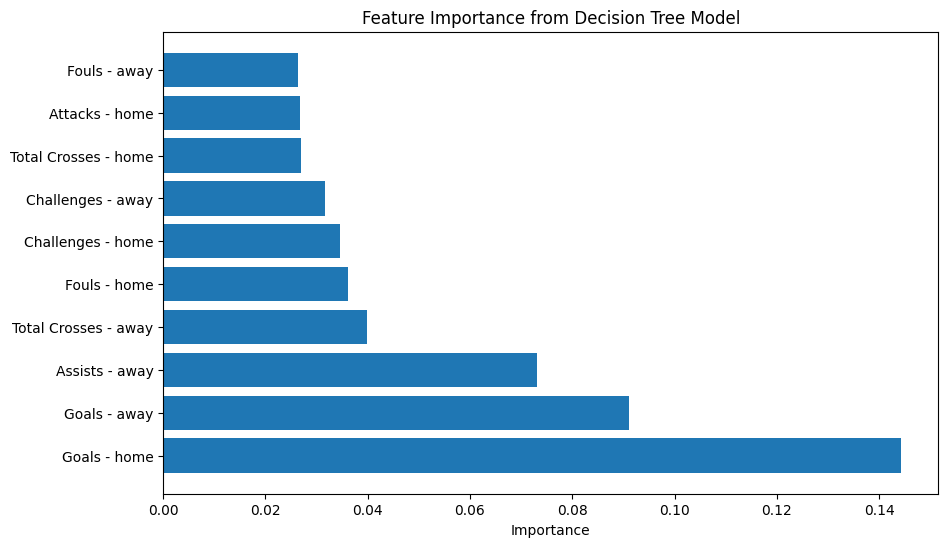

```python
# Get the feature importances
feature_importances = best_model.feature_importances_

feature_names = list(X.columns)
importance_df = pd.DataFrame({
    'Feature': feature_names,
    'Importance': feature_importances
})

importance_df = importance_df.sort_values(by='Importance', ascending=False)
top_10_features = importance_df.head(10)

# Plot the feature importances
plt.figure(figsize=(10, 6))
plt.barh(top_10_features['Feature'], top_10_features['Importance'])
plt.xlabel('Importance')
plt.title('Feature Importance from Decision Tree Model')
plt.show()
```

1. **Most Important Features:** The features "Goals - home" and "Goals - away" are the most important, as expected, since goals are the primary determinant of match outcomes.
2. **Assists:** Assists are also highly important, as they indirectly provide insight into the likelihood of goals, reflecting offensive team performance.
3. **Total Crosses:** Total crosses are likely a key indicator of offensive pressure, such as approaching the box, taking shots, or even the goalkeeper’s actions in preventing goals. This makes it an important factor in predicting match outcomes.
4. **Other Features:** Other features, such as Challenges and Fouls, show somewhat similar importance. From the chart, it is evident that these are also significant factors influencing the model’s predictions.

```
Accuracy: 0.83
F1 Score: 0.82
```

[figure not shown]

```python
y_pred = best_model.predict(X_test)

cm = confusion_matrix(y_test, y_pred)
disp = ConfusionMatrixDisplay(confusion_matrix=cm, display_labels=['Home', 'Away', 'Draw'])
disp.plot()

accuracy = accuracy_score(y_test, y_pred)
f1 = f1_score(y_test, y_pred, average='weighted')

print(f"Accuracy: {accuracy:.2f}")
print(f"F1 Score: {f1:.2f}")
```

```python
# Create a comparison df in order to compare the predicted probabilities of the decision tree and the implied probabilities

test_set_ids = X_test.index
normalized_probs_test_set = filtered_data.loc[test_set_ids, ['Prob_normalize_1', 'Prob_normalize_2', 'Prob_normalize_X']]
normalized_probs_test_set

predicted_probs_df = pd.DataFrame(y_proba, columns=['Pred_Draw', 'Pred_Home', 'Pred_Away'])
comparison_df = pd.DataFrame(normalized_probs_test_set.values, columns=['Norm_Home', 'Norm_Away', 'Norm_Draw'])
comparison = pd.concat([predicted_probs_df, comparison_df], axis=1)
comparison = comparison[['Pred_Home', 'Pred_Away', 'Pred_Draw', 'Norm_Home', 'Norm_Away', 'Norm_Draw']]

comparison['Diff_Home'] = comparison['Pred_Home'] - comparison['Norm_Home']
comparison['Diff_Away'] = comparison['Pred_Away'] - comparison['Norm_Away']
comparison['Diff_Draw'] = comparison['Pred_Draw'] - comparison['Norm_Draw']

comparison
```

|  | Pred_Home | Pred_Away | Pred_Draw | Norm_Home | Norm_Away | Norm_Draw | Diff_Home | Diff_Away | Diff_Draw |
| --- | --- | --- | --- | --- | --- | --- | --- | --- | --- |
| 0 | 0.195833 | 0.100000 | 0.704167 | 0.368421 | 0.263158 | 0.368421 | -0.172588 | -0.163158 | 0.335746 |
| 1 | 1.000000 | 0.000000 | 0.000000 | 0.933949 | 0.001920 | 0.064131 | 0.066051 | -0.001920 | -0.064131 |
| 2 | 0.000000 | 0.000000 | 1.000000 | 0.232726 | 0.508690 | 0.258584 | -0.232726 | -0.508690 | 0.741416 |
| 3 | 0.000000 | 0.000000 | 1.000000 | 0.055444 | 0.654543 | 0.290013 | -0.055444 | -0.654543 | 0.709987 |
| 4 | 0.434868 | 0.309500 | 0.255632 | 0.667656 | 0.124629 | 0.207715 | -0.232788 | 0.184871 | 0.047917 |
| ... | ... | ... | ... | ... | ... | ... | ... | ... | ... |
| 11221 | 0.047009 | 0.850427 | 0.102564 | 0.207317 | 0.518293 | 0.274390 | -0.160309 | 0.332135 | -0.171826 |
| 11222 | 0.000000 | 1.000000 | 0.000000 | 0.251681 | 0.419468 | 0.328851 | -0.251681 | 0.580532 | -0.328851 |
| 11223 | 0.300000 | 0.000000 | 0.700000 | 0.866031 | 0.009261 | 0.124708 | -0.566031 | -0.009261 | 0.575292 |
| 11224 | 0.000000 | 1.000000 | 0.000000 | 0.076923 | 0.738462 | 0.184615 | -0.076923 | 0.261538 | -0.184615 |
| 11225 | 1.000000 | 0.000000 | 0.000000 | 0.781250 | 0.062500 | 0.156250 | 0.218750 | -0.062500 | -0.156250 |

11226 rows × 9 columns

[figure not shown]

```python
plt.figure(figsize=(10, 6))

# Plot a sample of 50 difference column
plt.plot(comparison.index[:50], comparison['Diff_Draw'][:50], label='Diff_Draw', color='blue', linestyle='-')

plt.title('Comparison of Predicted and Implied Probabilities', fontsize=14)
plt.xlabel('Sample Index', fontsize=12)
plt.ylabel('Difference (Predicted - Normalized)', fontsize=12)

plt.legend()
plt.tight_layout()
plt.show()
```

This chart illustrates several instances where the predicted probability of a draw, derived from our decision tree classifier, is significantly higher than the implied probability, which is calculated from the odds and their normalization. In these cases, it would be logical to bet on a draw, as our decision tree classifier demonstrates an 83% accuracy and a 82% f1-score. When the predicted probability exceeds the odds-based probability by a substantial margin, it suggests that the model has identified an opportunity where the draw is undervalued, and betting on it could be profitable, given that the model is trained on game statistics.

However, there are also instances where the predicted probability of a draw is much lower than the implied probability. In these cases, betting on a draw is not sensible. The lower predictions are likely due to the following reason: early in the game, there is often insufficient match data to accurately predict the outcome. At this stage, the model lacks historical information about previous encounters between the teams, their relative strengths, and other contextual factors. The implied probabilities, on the other hand, incorporate this additional context, which our decision tree cannot account for. Therefore, in such situations, it would be illogical to bet on a draw.

## Challenges Faced During the Project

1. **Evaluating the Bias between Odds Probabilities and Empirical Probabilities:** As seen in the graphs above, there are many instances where the odds probabilities are significantly higher than the empirical probabilities. Determining how to comment on this bias was challenging. Since the odds probabilities exhibited a quadratic trend, I fitted a quadratic line to the data and based my analysis on that trend.
2. **Determining the Hyperparameters for the Decision Tree:** I used Optuna to optimize the hyperparameters and enhance the model's accuracy. However, Optuna consistently selected the upper bound for the **max_depth** parameter. My concern was that such a deep tree could lead to overfitting, and would reduce the interpretability of the model. After comparing different scenarios, I found that accuracy significantly dropped with shallower trees, so I decided to retain a higher max_depth to maintain accuracy.